# Biostat 203B Homework 5

Due Mar 22 @ 11:59PM

Author

Chengwu Duan and 606332825

## Predicting ICU duration

Using the ICU cohort `mimiciv_icu_cohort.rds` you built in Homework 4, develop at least three machine learning approaches (logistic regression with enet regularization, random forest, boosting, SVM, MLP, etc) plus a model stacking approach for predicting whether a patient’s ICU stay will be longer than 2 days. You should use the `los_long` variable as the outcome. Your algorithms can use patient demographic information (gender, age at ICU `intime`, marital status, race), ICU admission information (first care unit), the last lab measurements before the ICU stay, and first vital measurements during ICU stay as features. You are welcome to use any feature engineering techniques you think are appropriate; but make sure to not use features that are not available at an ICU stay’s `intime`. For instance, `last_careunit` cannot be used in your algorithms.

### 1.

Data preprocessing and feature engineering.

**Answer:** Done in hw5Preprocess.qmd, will be using the result rds here.

```r
# Load libraries
library(GGally)
library(gtsummary)
library(ranger)
library(keras)
library(stacks)
library(tidyverse)
library(tidymodels)
library(vip)
library(ggplot2)

# load data
mimiciv_icu_cohort <- read_rds("./mimiciv_icu_cohort_postprocessed.rds")
```

### 2.

Partition data into 50% training set and 50% test set. Stratify partitioning according to `los_long`. For grading purpose, sort the data by `subject_id`, `hadm_id`, and `stay_id` and use the seed `203` for the initial data split. Below is the sample code.

```r
set.seed(203)

# sort
mimiciv_icu_cohort <- mimiciv_icu_cohort %>%
  arrange(subject_id, hadm_id, stay_id)

data_split <- initial_split(
  mimiciv_icu_cohort,
  # stratify by los_long
  strata = "los_long",
  prop = 0.5
  )

mimic_train <- training(data_split)
dim(mimic_train)
```

```
[1] 36590    27
```

```r
mimic_test <- testing(data_split)
dim(mimic_test)
```

```
[1] 36591    27
```

```r
# checking for missing values
summary(mimiciv_icu_cohort)
```

```
   subject_id          hadm_id            stay_id
 Min.   :10000032   Min.   :20000094   Min.   :30000153
 1st Qu.:12491257   1st Qu.:22483349   1st Qu.:32489353
 Median :14998941   Median :24969636   Median :34993892
 Mean   :14998189   Mean   :24981328   Mean   :34992735
 3rd Qu.:17513267   3rd Qu.:27471796   3rd Qu.:37488401
 Max.   :19999987   Max.   :29999828   Max.   :39999810

                                          first_careunit
 Cardiac Vascular Intensive Care Unit (CVICU)    :11582
 Medical Intensive Care Unit (MICU)              :15898
 Medical/Surgical Intensive Care Unit (MICU/SICU):12733
 Surgical Intensive Care Unit (SICU)             :11161
 Other                                           :21807


                     admission_type               admission_location
 EW EMER.                   :38672   EMERGENCY ROOM        :35881
 OBSERVATION ADMIT          : 8974   PHYSICIAN REFERRAL    :16398
 SURGICAL SAME DAY ADMISSION: 7373   TRANSFER FROM HOSPITAL:15798
 URGENT                     :12453   Other                 : 5104
 Other                      : 5709


  insurance           language         marital_status           race
 Length:73181       Length:73181       Length:73181       ASIAN   : 2155
 Class :character   Class :character   Class :character   BLACK   : 7960
 Mode  :character   Mode  :character   Mode  :character   HISPANIC: 2741
                                                          WHITE   :49569
                                                          Other   :10756


    gender            age_intime      bicarbonate       chloride
 Length:73181       Min.   : 18.00   Min.   : 2.00   Min.   : 45.0
 Class :character   1st Qu.: 54.00   1st Qu.:22.00   1st Qu.: 98.0
 Mode  :character   Median : 66.00   Median :25.00   Median :102.0
                    Mean   : 64.68   Mean   :24.34   Mean   :101.2
                    3rd Qu.: 77.00   3rd Qu.:27.00   3rd Qu.:105.0
                    Max.   :102.00   Max.   :50.00   Max.   :144.0
                                     NA's   :9035    NA's   :8869
```

[output cut: 17 more lines]

```
 Min.   :    0.00                      Min.   :    0.0
 1st Qu.:   57.00                      1st Qu.:  106.0
 Median :   67.00                      Median :  121.0
 Mean   :   71.35                      Mean   :  123.2
 3rd Qu.:   79.00                      3rd Qu.:  139.0
 Max.   :82127.00                      Max.   :12262.0
 NA's   :983                           NA's   :979
 respiratory_rate temperature_fahrenheit  los_long      intime_hour
 Min.   :  0.00   Min.   :  0.00         FALSE:38050   Min.   : 0.00
 1st Qu.: 15.00   1st Qu.: 97.60         TRUE :35131   1st Qu.: 8.00
 Median : 18.00   Median : 98.20                       Median :14.00
 Mean   : 19.07   Mean   : 98.07                       Mean   :12.79
 3rd Qu.: 22.00   3rd Qu.: 98.70                       3rd Qu.:19.00
 Max.   :180.00   Max.   :998.90                       Max.   :23.00
 NA's   :98       NA's   :1362
```

```r
mimiciv_icu_cohort %>% tbl_summary()
```

| **Characteristic** | **N = 73,181**<sup>1</sup> |
| --- | --- |
| subject_id | 14,998,941 (12,491,257, 17,513,267) |
| hadm_id | 24,969,636 (22,483,349, 27,471,796) |
| stay_id | 34,993,892 (32,489,353, 37,488,401) |
| first_careunit |  |
| Cardiac Vascular Intensive Care Unit (CVICU) | 11,582 (16%) |
| Medical Intensive Care Unit (MICU) | 15,898 (22%) |
| Medical/Surgical Intensive Care Unit (MICU/SICU) | 12,733 (17%) |
| Surgical Intensive Care Unit (SICU) | 11,161 (15%) |
| Other | 21,807 (30%) |
| admission_type |  |
| EW EMER. | 38,672 (53%) |
| OBSERVATION ADMIT | 8,974 (12%) |
| SURGICAL SAME DAY ADMISSION | 7,373 (10%) |
| URGENT | 12,453 (17%) |
| Other | 5,709 (7.8%) |
| admission_location |  |
| EMERGENCY ROOM | 35,881 (49%) |
| PHYSICIAN REFERRAL | 16,398 (22%) |
| TRANSFER FROM HOSPITAL | 15,798 (22%) |
| Other | 5,104 (7.0%) |
| insurance |  |
| Medicaid | 5,528 (7.6%) |
| Medicare | 33,091 (45%) |
| Other | 34,562 (47%) |
| language |  |
| ? | 7,443 (10%) |
| ENGLISH | 65,738 (90%) |
| marital_status |  |
| DIVORCED | 5,404 (7.9%) |
| MARRIED | 32,768 (48%) |
| SINGLE | 20,858 (31%) |
| WIDOWED | 9,038 (13%) |
| Unknown | 5,113 |
| race |  |
| ASIAN | 2,155 (2.9%) |
| BLACK | 7,960 (11%) |
| HISPANIC | 2,741 (3.7%) |
| WHITE | 49,569 (68%) |
| Other | 10,756 (15%) |
| gender |  |
| F | 32,363 (44%) |
| M | 40,818 (56%) |
| age_intime | 66 (54, 77) |
| bicarbonate | 25.0 (22.0, 27.0) |
| Unknown | 9,035 |
| chloride | 102 (98, 105) |
| Unknown | 8,869 |
| creatinine | 1.00 (0.80, 1.50) |
| Unknown | 5,754 |
| glucose | 120 (99, 156) |
| Unknown | 9,084 |
| hematocrit | 35 (30, 40) |
| Unknown | 5,015 |
| potassium | 4.20 (3.80, 4.60) |
| Unknown | 8,888 |
| sodium | 139.0 (136.0, 141.0) |
| Unknown | 8,858 |
| wbc | 9.3 (6.8, 13.2) |
| Unknown | 5,092 |
| heart_rate | 86 (74, 101) |
| Unknown | 18 |
| non_invasive_blood_pressure_diastolic | 67 (57, 79) |
| Unknown | 983 |
| non_invasive_blood_pressure_systolic | 121 (106, 139) |
| Unknown | 979 |
| respiratory_rate | 18.0 (15.0, 22.0) |
| Unknown | 98 |
| temperature_fahrenheit | 98.20 (97.60, 98.70) |
| Unknown | 1,362 |
| los_long |  |
| FALSE | 38,050 (52%) |
| TRUE | 35,131 (48%) |
| intime_hour | 14 (8, 19) |

<sup>1</sup> Median (IQR); n (%)

### 3.

Train and tune the models using the training set.

```r
# eval = F to only have to run model once after tuning process
library(xgboost)
library(doParallel)

gb_recipe <-
  recipe(
    los_long ~ .,
    data = mimic_train
  ) %>%
  # mean imputation for Ca
  step_impute_mean(all_numeric_predictors()) %>%
  # mode imputation for Thal
  step_impute_mode(all_nominal_predictors()) %>%
  # create traditional dummy variables (necessary for xgboost)
  step_dummy(all_nominal_predictors()) %>%
  # zero-variance filter
  step_zv(all_numeric_predictors())

gb_mod <-
  boost_tree(
    mode = "classification",
    trees = 1000,
    tree_depth = tune(),
    learn_rate = tune()
  ) %>%
  set_engine("xgboost")
gb_mod

gb_wf <- workflow() %>%
  add_recipe(gb_recipe) %>%
  add_model(gb_mod)
gb_wf

write_rds(gb_wf, "gb_wf.rds")

param_grid <- grid_regular(
  tree_depth(range = c(1L, 3L)),
  learn_rate(range = c(-5, 2), trans = log10_trans()),
  levels = c(3, 10)
  )
param_grid

set.seed(203)

folds <- vfold_cv(mimic_train, v = 5)
folds

# Register doParallel as the parallel backend
# saving 2 cpu for other tasks
registerDoParallel(cores = detectCores()-2)

(gb_fit <- gb_wf %>%
  tune_grid(
    resamples = folds,
    grid = param_grid,
    metrics = metric_set(roc_auc, accuracy)
    )) %>%
  system.time()

# stop the registered parallel backend
stopImplicitCluster()

gb_fit

write_rds(gb_fit, "gb_fit.rds")
```

```r
gb_fit = read_rds("gb_fit.rds")
gb_wf = read_rds("gb_wf.rds")

gb_fit %>%
  show_best(metric = "roc_auc")
```

```
# A tibble: 5 × 8
  tree_depth learn_rate .metric .estimator  mean     n std_err .config
       <int>      <dbl> <chr>   <chr>      <dbl> <int>   <dbl> <chr>
1          2     0.0774 roc_auc binary     0.658     5 0.00283 Preprocessor1_Mo…
2          3     0.0774 roc_auc binary     0.657     5 0.00268 Preprocessor1_Mo…
3          3     0.0129 roc_auc binary     0.657     5 0.00355 Preprocessor1_Mo…
4          1     0.464  roc_auc binary     0.650     5 0.00259 Preprocessor1_Mo…
5          1     0.0774 roc_auc binary     0.649     5 0.00306 Preprocessor1_Mo…
```

```r
best_gb <- gb_fit %>%
  select_best(metric = "roc_auc")
best_gb
```

```
# A tibble: 1 × 3
  tree_depth learn_rate .config
       <int>      <dbl> <chr>
1          2     0.0774 Preprocessor1_Model17
```

```
# A tibble: 60 × 8
   tree_depth learn_rate .metric  .estimator  mean     n std_err
        <int>      <dbl> <chr>    <chr>      <dbl> <int>   <dbl>
 1          1  0.00001   accuracy binary     0.550     5 0.00338
 2          1  0.00001   roc_auc  binary     0.539     5 0.00172
 3          2  0.00001   accuracy binary     0.558     5 0.00253
 4          2  0.00001   roc_auc  binary     0.561     5 0.00307
 5          3  0.00001   accuracy binary     0.564     5 0.00270
 6          3  0.00001   roc_auc  binary     0.575     5 0.00454
 7          1  0.0000599 accuracy binary     0.550     5 0.00338
 8          1  0.0000599 roc_auc  binary     0.539     5 0.00172
 9          2  0.0000599 accuracy binary     0.559     5 0.00255
10          2  0.0000599 roc_auc  binary     0.571     5 0.00440
   .config
   <chr>
 1 Preprocessor1_Model01
 2 Preprocessor1_Model01
 3 Preprocessor1_Model02
 4 Preprocessor1_Model02
 5 Preprocessor1_Model03
 6 Preprocessor1_Model03
 7 Preprocessor1_Model04
 8 Preprocessor1_Model04
 9 Preprocessor1_Model05
10 Preprocessor1_Model05
# ℹ 50 more rows
```

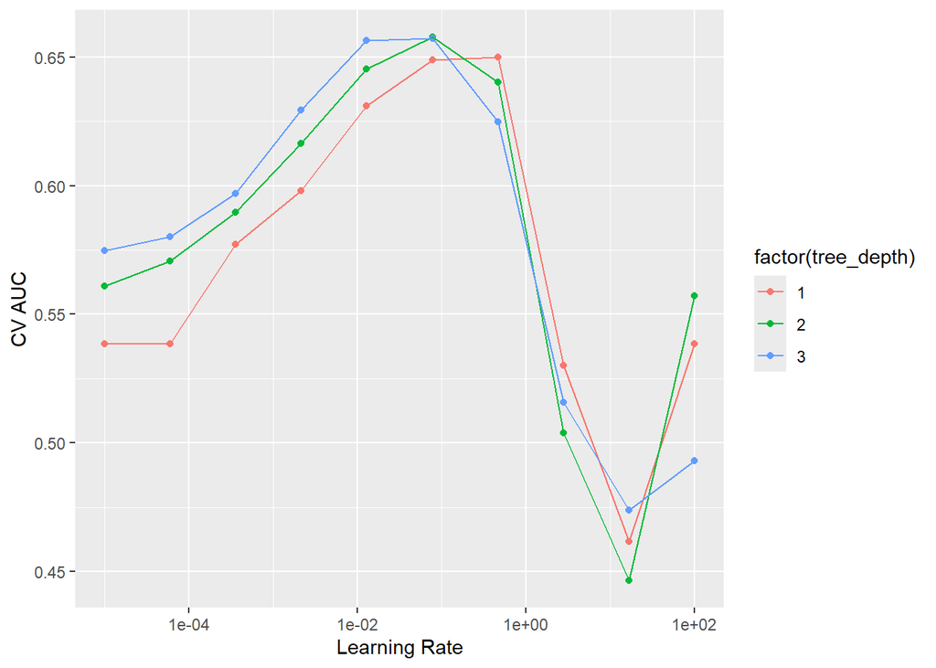

```r
gb_fit %>%
  collect_metrics() %>%
  print(width = Inf) %>%
  filter(.metric == "roc_auc") %>%
  ggplot(mapping = aes(x = learn_rate, y = mean, color = factor(tree_depth))) +
  geom_point() +
  geom_line() +
  labs(x = "Learning Rate", y = "CV AUC") +
  scale_x_log10()
```

```r
# Final workflow
final_wf <- gb_wf %>%
  finalize_workflow(best_gb)
final_wf
```

```
══ Workflow ════════════════════════════════════════════════════════════════════
Preprocessor: Recipe
Model: boost_tree()

── Preprocessor ────────────────────────────────────────────────────────────────
4 Recipe Steps

• step_impute_mean()
• step_impute_mode()
• step_dummy()
• step_zv()

── Model ───────────────────────────────────────────────────────────────────────
Boosted Tree Model Specification (classification)

Main Arguments:
  trees = 1000
  tree_depth = 2
  learn_rate = 0.0774263682681127

Computational engine: xgboost
```

```r
# Fit the whole training set, then predict the test cases
final_fit <-
  final_wf %>%
  last_fit(data_split)
final_fit
```

```
# Resampling results
# Manual resampling
# A tibble: 1 × 6
  splits                id             .metrics .notes   .predictions .workflow
  <list>                <chr>          <list>   <list>   <list>       <list>
1 <split [36590/36591]> train/test sp… <tibble> <tibble> <tibble>     <workflow>
```

```r
# Test metrics
final_fit %>%
  collect_metrics()
```

```
# A tibble: 3 × 4
  .metric     .estimator .estimate .config
  <chr>       <chr>          <dbl> <chr>
1 accuracy    binary         0.612 Preprocessor1_Model1
2 roc_auc     binary         0.657 Preprocessor1_Model1
3 brier_class binary         0.231 Preprocessor1_Model1
```

```r
# for easier reporducing
gb_wf <- read_rds("gb_wf.rds")

param_grid <- grid_regular(
  tree_depth(range = c(1L, 3L)),
  learn_rate(range = c(-5, 2), trans = log10_trans()),
  levels = c(3, 10)
  )

set.seed(203)
folds <- vfold_cv(mimic_train, v = 5)
```

```r
# Saving the results for the stacked model
library(doParallel)
# Register doParallel as the parallel backend
# saving 2 cpu for other tasks
registerDoParallel(cores = detectCores()-2)

# saving results for stacked model
gb_res <-
  tune_grid(
    object = gb_wf,
    resamples = folds,
    grid = param_grid,
    control = control_stack_grid()
  )

# stop the registered parallel backend
stopImplicitCluster()

write_rds(gb_res, "gb_res.rds")
```

### 4.

Compare model classification performance on the test set. Report both the area under ROC curve and accuracy for each machine learning algorithm and the model stacking. Interpret the results. What are the most important features in predicting long ICU stays? How do the models compare in terms of performance and interpretability?

#### The importance of features in predicting long ICU stays

```r
library(vip)

#library(rpart.plot)
final_tree <- extract_workflow(final_fit)
final_tree
```

[output not shown]

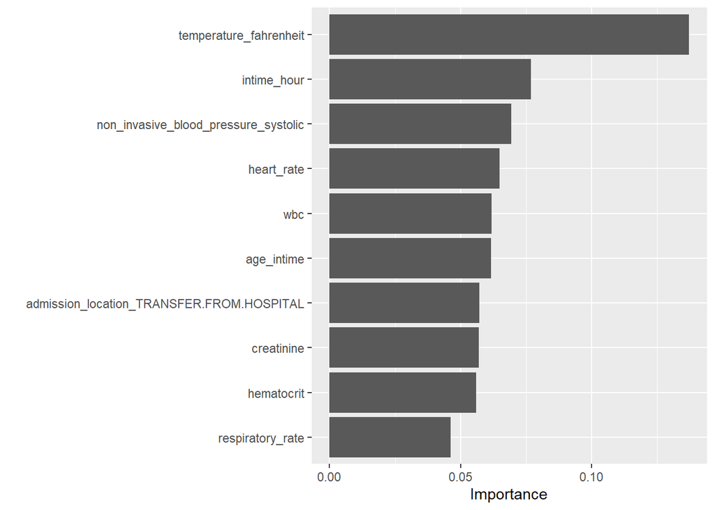

```r
final_tree %>%
  extract_fit_parsnip() %>%
  vip()
```

#### Interpretation of the results

**Answer:** The boosting model has an CV AUC of 0.658, test AUC of 0.657 and an accuracy of 0.612. The model is interpretable and has a decent performance.